# DATS6101 Group Project: App Analysis

Jonathan Giguere, Jesse Borg, Ese Emuraye, Sarah Gates

October 23rd 2019

## Section 1: Introduction

The popularity of smartphones has increased greatly every year since Apple released the Iphone in 2007, with approximately 10 billion [Statista](https://statista.com) smartphones sold worldwide since then. Of these 10 billion; iPhones account for almost 20% of sales with a total revenue of $165 billion in 2018 alone [CEO World Magazine](https://ceoworld.biz). Since the meteoric rise of the smartphone and tech industries, many app developers have taken the opportunity to develop their own apps for different operating systems and made them available to download on the App Store and/or the Google Play Store. Today, there are over 2.2 billion iOS apps [Lifewire](https://lifewire.com) and 2.7 billion apps on the Google Play Store [Statista](https://statista.com). On average, people spend around 3 hours a day on their phones [Hacker Noon](https://hackernoon.com). Due to the huge popularity of apps, there is a wide variety of genres available for every type of audience with a wide range of pricing. Since many people invest so much time and effort into apps, app data has become an interesting and relevant topic to conduct more research on.

## Section 2: Description of Data

### 2.1 Discussion of Data Sources

The data for our EDA comes from two datasets that our team discovered on [Kaggle](https://www.kaggle.com). The first dataset contains information about apps in the Google Play Store. The second contains information about apps in the App Store. First, we will describe the data pertaining to the Google Play Store.

#### Google Play Store Data

The Google Play Store dataset contains records for 10,840 different apps. The variables, and their descriptions are given below:

- **App** - The name of the application
- **Category** - The category that the app belongs in
- **Rating** - The current app rating on a scale from 1 to 5 (1 being the lowest)
- **Reviews** - The number of reviews for the app
- **Size** - Size of the app given in MB
- **Installs** - Number of installs given as categories (ex. 10,000+)
- **Type** - Tells which apps are free and which require payment
- **Price** - Gives the Price for each app
- **Content_Rating** - Indicates which age groups the app is approved for
- **Genres** - A further breakdown of the Category variable for each app
- **Last Updated** - Date the app was last updated
- **Current.Ver** - Current Version of the app

```
## 'data.frame':    10840 obs. of  12 variables:
##  $ App           : Factor w/ 9659 levels "\"i DT\" FÃºtbol. Todos Somos TÃ©cnicos.",..: 7228 2563 8997 8112 7293 7124 8170 5589 4948 5826 ...
##  $ Category      : Factor w/ 33 levels "ART_AND_DESIGN",..: 1 1 1 1 1 1 1 1 1 1 ...
##  $ Rating        : num  4.1 3.9 4.7 4.5 4.3 4.4 3.8 4.1 4.4 4.7 ...
##  $ Reviews       : int  159 967 87510 215644 967 167 178 36815 13791 121 ...
##  $ Size          : chr  "19" "14" "8.7" "25" ...
##  $ Installs      : Factor w/ 21 levels "0","0+","1,000,000,000+",..: 8 20 13 16 11 17 17 4 4 8 ...
##  $ Type          : Factor w/ 3 levels "Free","NaN","Paid": 1 1 1 1 1 1 1 1 1 1 ...
##  $ Price         : Factor w/ 92 levels "$0.99","$1.00",..: 92 92 92 92 92 92 92 92 92 92 ...
##  $ Content.Rating: Factor w/ 6 levels "Adults only 18+",..: 2 2 2 5 2 2 2 2 2 2 ...
##  $ Genres        : Factor w/ 119 levels "Action","Action;Action & Adventure",..: 10 13 10 10 12 10 10 10 10 12 ...
##  $ Last.Updated  : Factor w/ 1377 levels "April 1, 2016",..: 561 481 116 824 756 900 75 725 1316 669 ...
##  $ Current.Ver   : Factor w/ 2785 levels "","0.0.0.2","0.0.1",..: 117 998 460 2778 274 110 274 2346 1430 1404 ...
```

#### Apple Store Data

The Apple App Store dataset contains records for 7,197 different apps. The variables, and their descriptions are given below:

- **App** - The name of the application
- **Category** - The category that the app belongs in
- **Rating** - The current app rating on a scale from 1 to 5 (1 being the lowest)
- **Reviews** - The number of reviews for the app
- **Size** - Size of the app given in MB
- **Price** - Gives the Price for each app
- **Content_Rating** - Indicates which age groups the app is approved for
- **Current_Ver** - Current_Version of the app

```
## 'data.frame':    7197 obs. of  9 variables:
##  $ X             : int  1 2 3 4 5 6 7 8 9 10 ...
##  $ App           : Factor w/ 7195 levels "-The ç©´é\200šã\201—3D- å\220›ã\201®è¨\230æ†¶åŠ›xå\217\215å°„ç¥žçµŒã‚’å•\217ã\201†! ï½žMr.CURVEã\201‹ã‚‰ã\201®æŒ‘æ\210¦çŠ¶ ï½ž",..: 4747 2617 6946 2479 1169 5572 4820 4766 4823 4357 ...
##  $ Size          : num  101 159 101 129 93 10 228 130 49 70 ...
##  $ Price         : num  3.99 0 0 0 0 0.99 0 0 9.99 3.99 ...
##  $ Reviews       : int  21292 161065 188583 262241 985920 8253 119487 1126879 1117 7885 ...
##  $ Rating        : num  4 4 3.5 4 4.5 4 4 4 4.5 4 ...
##  $ Current_Ver   : Factor w/ 1590 levels "0.0.15","0.13",..: 1380 1515 1211 1237 1473 455 1360 1523 1009 1068 ...
##  $ Content_Rating: Factor w/ 4 levels "12+","17+","4+",..: 3 3 3 1 3 3 3 1 3 3 ...
##  $ Category      : Factor w/ 23 levels "Book","Business",..: 8 16 23 18 17 8 6 12 22 8 ...
```

### 2.2 Cleaning the Data

#### 2.2.1 Removing Null Values

First, we check how many null values are in the playstore data frame:

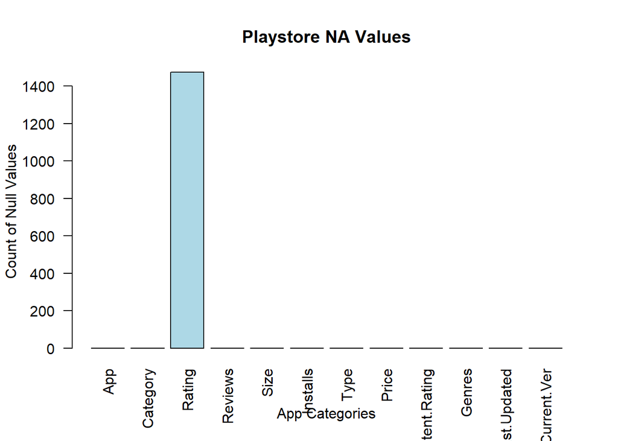

The only field with null values is Rating with 1474 missing values. We will store these values in a separate data frame in case we would like to do future analysis on this data. Then we will remove them from the main playstore dataset.

Now we will check whether there are duplicates. We will do this by checking the difference between all and unique object.

There are 1170 duplicates in the data. The next step is to remove duplicates from playstore.

The only field with null values is ‘Rating’, with 1474 missing values. We will store these values in a separate data frame in case we would like to do future analysis on this data. Then we will remove them from the main playstore dataset.

Next, to clean the data we will change the Installs variable from a nominal categorical variable to an ordinal categorical variable. Installs is a variable buckets the range of the number of times an app has been installed. We will place the factor levels in order from least to greatest.

## Section 3: Comparison of the App Store and Google Play Store

Even though the Google Play Store is going to be analyzed in this report, a comparative analysis will be made between the App Store and the Google Playstore. This will serve as a guide to the structure of each platform and provide a visual comparison between the two.

### 3.1 Variables comparison

Here we can see that the Google Playstore has more variables of interest than the Apple Appstore.

| Google Play Store | App Store |
| --- | --- |
| App | App |
| Category | Category |
| Rating | Rating |
| Reviews | Reviews |
| Size | Size |
| Installs | *N/A* |
| Type | *N/A* |
| Price | Price |
| Content.Rating | Content_Rating |
| Last.Updated | *N/A* |
| Current.Ver | Current_Ver |

### 3.2 Rating Distribution of Apps

Rating will most likely be a response variable of interest later in our analysis so we begin our comparison of the two app stores by looking at the distributions of ratings for each.

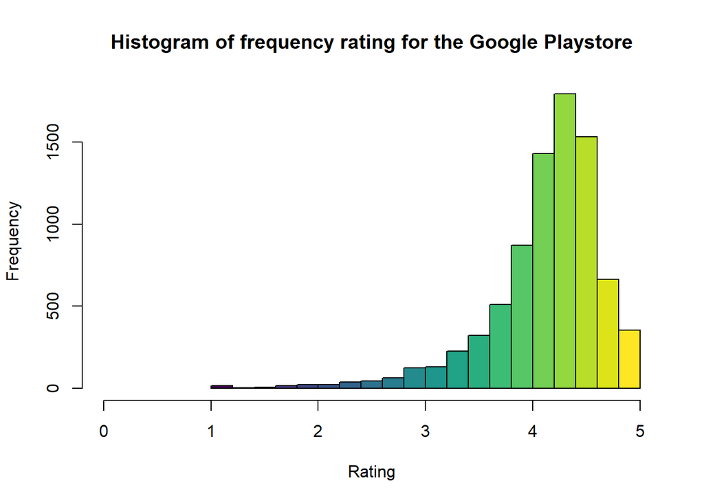

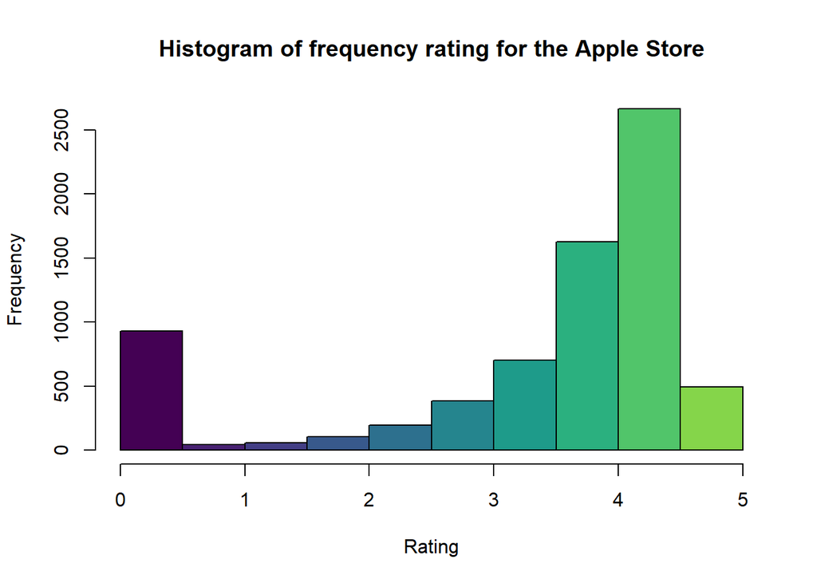

Upon inspection of the frequency distributions for each, we can see that neither is normally distributed and both are left skewed favoring higher rating. Due to the non-normal distributions, a two-sample t-test cannot be performed to evaluate the relationship between average ratings in each store. Instead we have simply calculated the mean and standard deviation of each for further comparison.

| Statistic | Google Playstore | App Store |
| --- | --- | --- |
| Mean | 4.17 | 3.53 |
| Standard Deviation | 0.54 | 1.52 |

We notice that The Google Playstore has a higher average rating for its apps than the Apple Appstore. We also notice that the variation in rating is lower in the Google Playstore. Some of this phenemenon could be attributed to the fact that the Google Playstore has ratings in incremencts of 0.1 while the Apple Appstore used increments of 0.5.

### 3.3 Apps in Both Datasets

After using the intersect() function to compare App names in both stores, there are a total of **328** apps in common. Now that we have dataframes containing common apps in both stores, we can revisit our ratings histogram to get a better idea of which store rates higher on average.

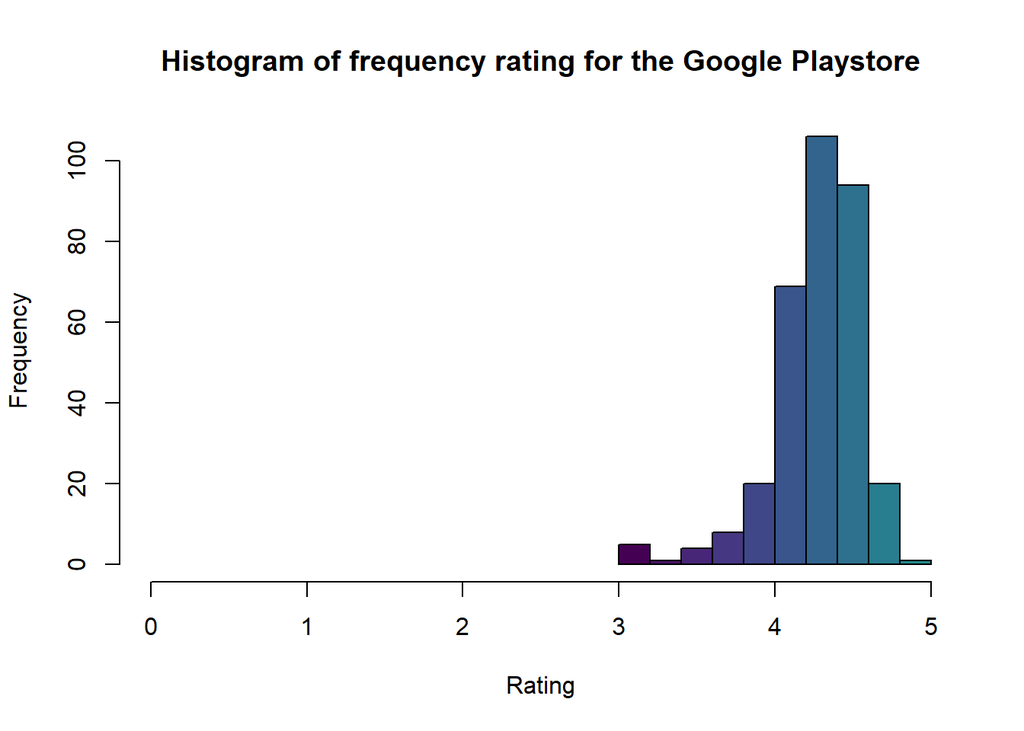

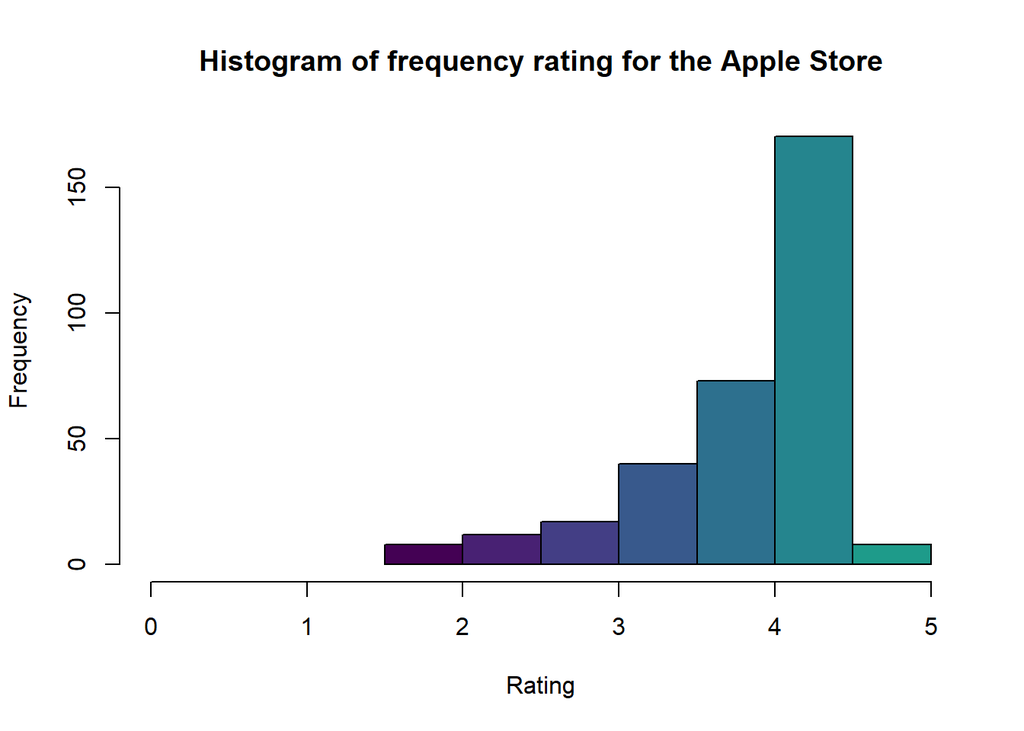

Once again, the histograms are left skewed and not normally distributed so performing a two-sided t-test would be inappropriate here. As such we have calculated mean and standard deviation of each below and compared it to the mean and standard deviation from above where all apps are considered.

[output not shown]

Once again, the Google Playstore has higher average ratings and than the Apple Appstore and less variation.

### 3.3 Apps in Both Datasets - Price Comparison

Before selecting one dataset to analyze further, we thought it would be wise to look at price comparisons between the two in case there are differences. In order to do so, we combined our dataframes consisting of all apps found in both stores. This allowed us to create a bar chart showing the sum of Price for each store for all **328** apps.

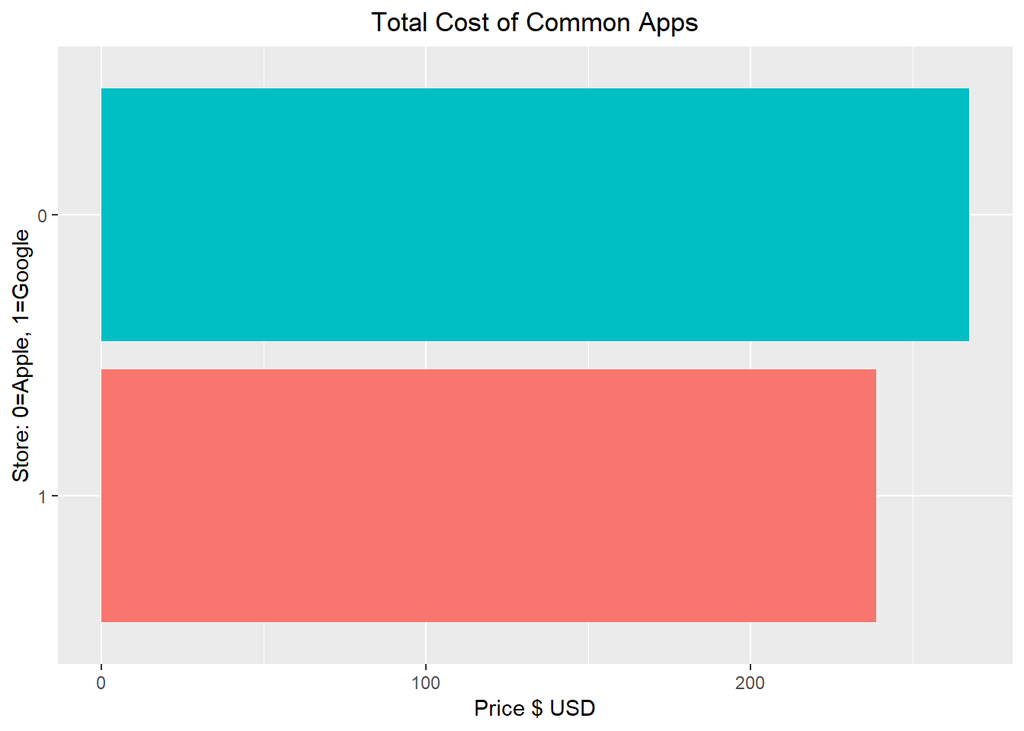

Upon inspection of the visual created, we can see that some of the same apps differ in price depending which store they are in. Based on the **328** apps the original datasets have in common, it would be more expensive to purchase all of them on the Apple app store. This could mean that the Apple app store is more expensive.

## Section 4: App Categories

### 4.1 SMART Question

Does app category have a correlation with rating, which categories in the Google Play Store have the highest priced apps and which category has the most highly rated apps?

### 4.2 Category Analysis

By grouping apps by category, we can determine the average rating by category and average price, as well as overall number of apps and number of apps by category. The most common categories are family, game and tools; below the category distrubution of apps is shown.

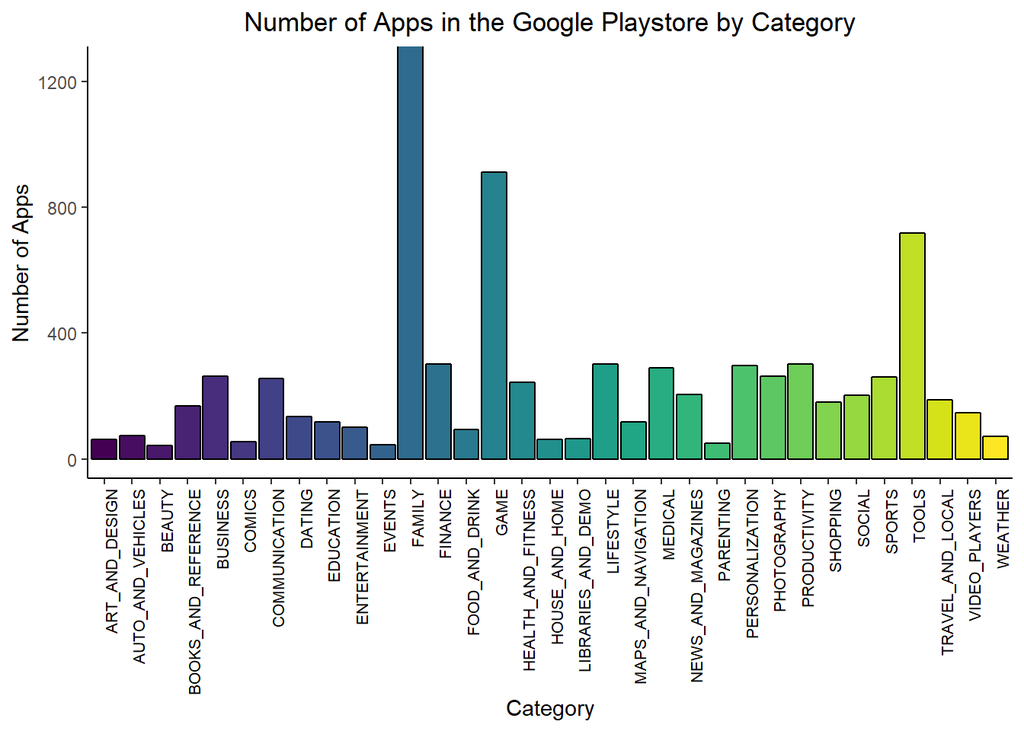

### 4.3

The highest rated categories on average are Events, Education and Art & Desgin, while the lowest rated categories are Maps & Navigation, Tools and Dating.

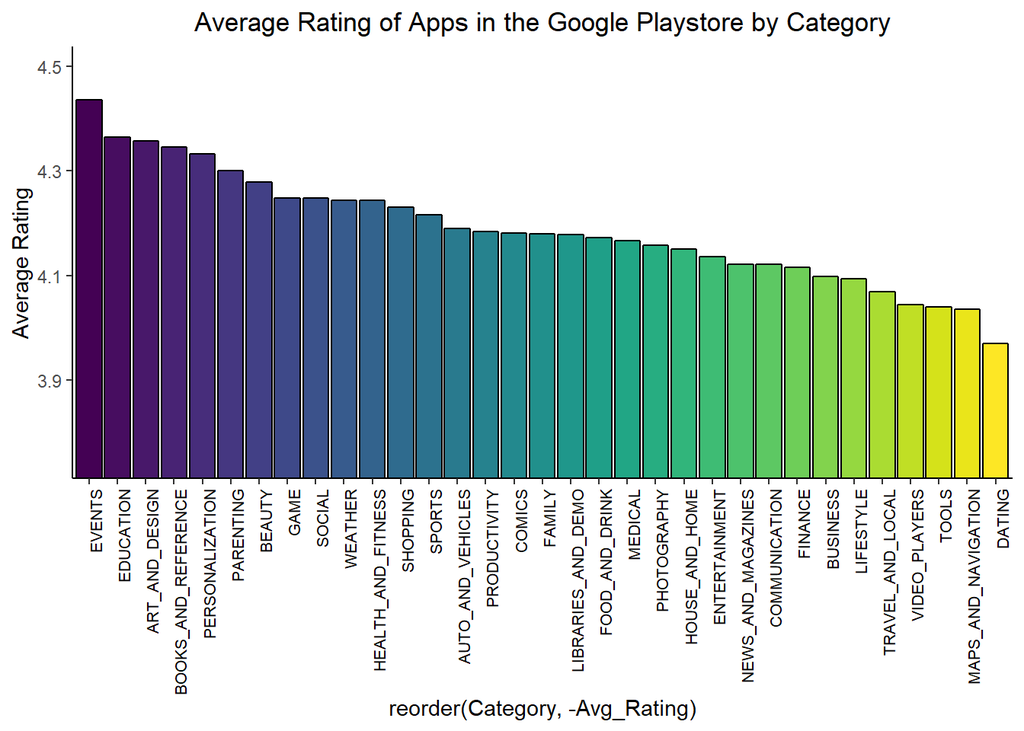

Highest Average Rating by Category

```
##               Category Avg_Rating
## 11              EVENTS   4.435556
## 9            EDUCATION   4.364407
## 1       ART_AND_DESIGN   4.357377
## 4  BOOKS_AND_REFERENCE   4.344970
## 24     PERSONALIZATION   4.332215
```

Lowest Average Rating by Category

```
##               Category Avg_Rating
## 31    TRAVEL_AND_LOCAL   4.069519
## 32       VIDEO_PLAYERS   4.044595
## 30               TOOLS   4.039554
## 20 MAPS_AND_NAVIGATION   4.036441
## 8               DATING   3.970149
```

### 4.4

Even though most of the apps in the Google Play Store are free; with 7592 free apps and 604 paid apps. Out of those paid apps, the most expensive ones on average are Finance and Lifestyle apps by a long shot.

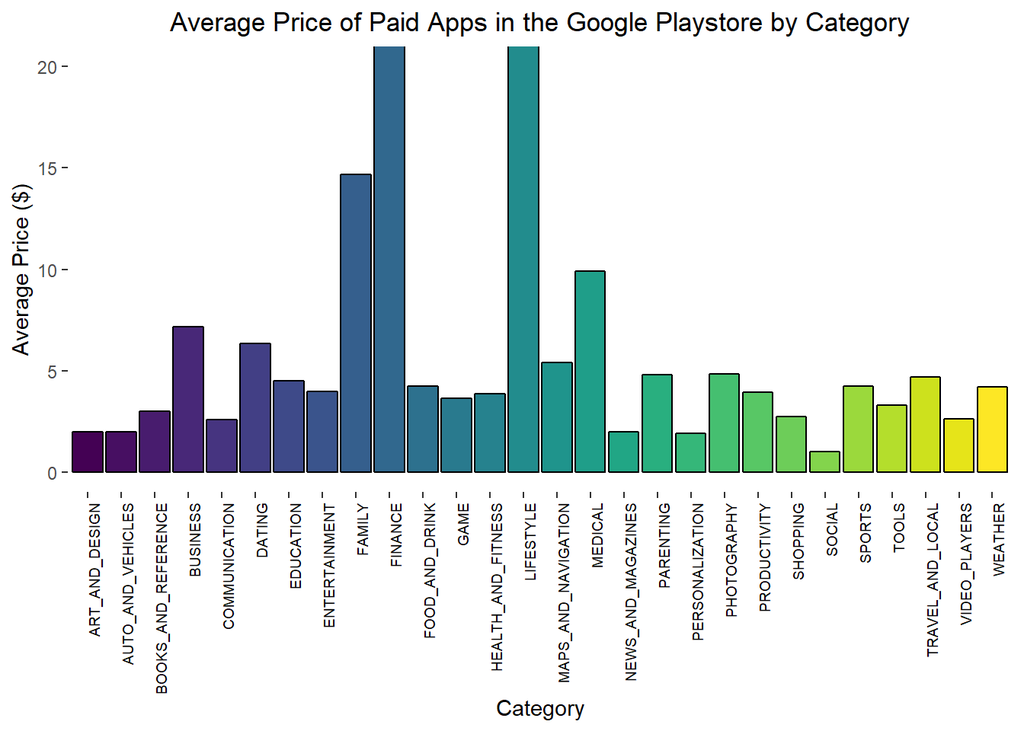

Highes Average Price by Category

```
##     Category  Avg_Price
## 10   FINANCE 187.682308
## 14 LIFESTYLE 108.937778
## 9     FAMILY  14.687143
## 16   MEDICAL   9.902698
## 4   BUSINESS   7.156667
```

### 4.5 Which app category in the Google Play Store receives most high ratings?

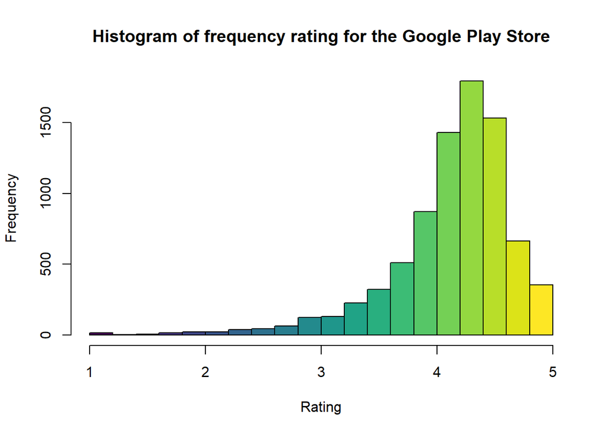

To do this, a new subset was created from the Google Play Store dataframe which only contained apps with a rating of 4.8 or greater. There are 577 apps which fall within the highly rated threshold of 4.8. After this, the number of apps from each catergory within this subset was done using the count function. This count was then plotted into a bar chart to graphically demonstrate the distrubution of high ratings within different categories.

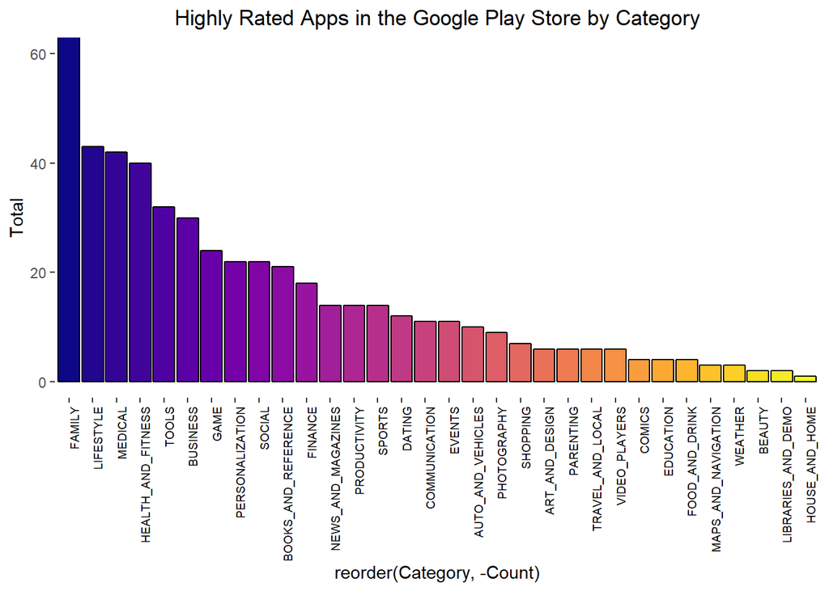

Catergories with the highest ratings are Family (by a large margin), then Medical, Lifestyle and Health & Fitness being very similar.

```
##              Category Count
## 11             FAMILY   134
## 18          LIFESTYLE    43
## 20            MEDICAL    42
## 15 HEALTH_AND_FITNESS    40
## 29              TOOLS    32
```

Overall; the highest rated apps on average are in the Events category, the most expensive apps are in the Finance category and the category with the most highly rated apps are Family.

## Section 5: App Pricing

KEY QUESTION: How does the price influence the distribution of apps across category, rating and content rating

```
## [1] 7592
```

```
## [1] 604
```

There are 7592 free apps and 604 paid apps corresponding to 92.6% and 7.37% respectively in Google playstore

How do users rate free and paid apps across different categories

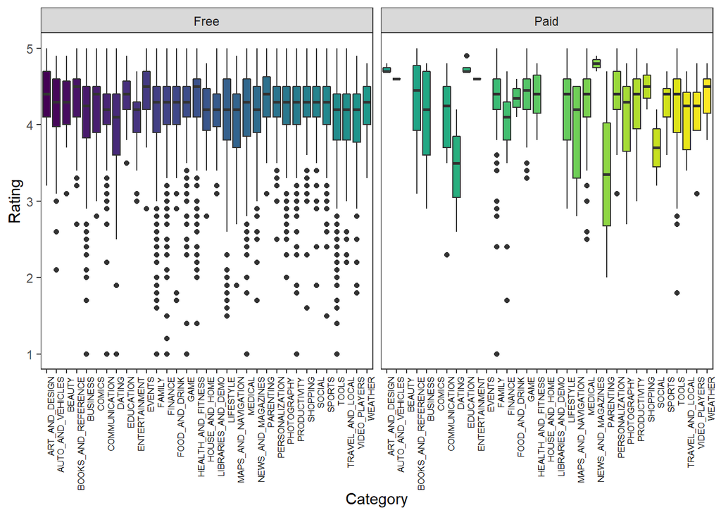

What kind of ratings does the different content rating categories have for both free and paid apps

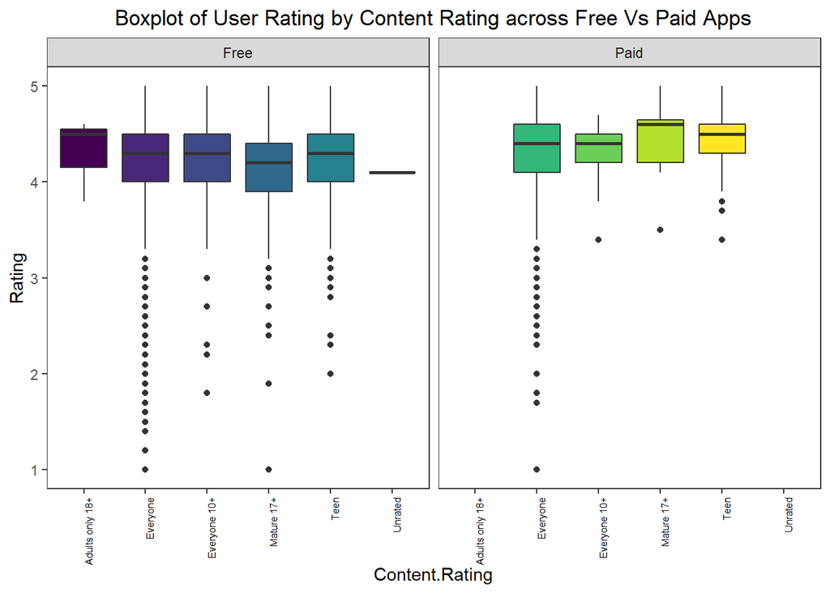

How are free apps distributed by category

```
## # A tibble: 33 x 2
##    Category           NumOfApps
##    <fct>                  <int>
##  1 BEAUTY                    42
##  2 EVENTS                    45
##  3 PARENTING                 48
##  4 COMICS                    54
##  5 ART_AND_DESIGN            58
##  6 HOUSE_AND_HOME            62
##  7 LIBRARIES_AND_DEMO        64
##  8 WEATHER                   65
##  9 AUTO_AND_VEHICLES         72
## 10 FOOD_AND_DRINK            92
## # ... with 23 more rows
```

[figure not shown]

```
## # A tibble: 5 x 2
##   Category       NumOfApps
##   <fct>              <int>
## 1 BEAUTY                42
## 2 EVENTS                45
## 3 PARENTING             48
## 4 COMICS                54
## 5 ART_AND_DESIGN        58
```

[figure not shown]

```
## # A tibble: 5 x 2
##   Category           NumOfApps
##   <fct>                  <int>
## 1 AUTO_AND_VEHICLES          1
## 2 ENTERTAINMENT              2
## 3 FOOD_AND_DRINK             2
## 4 NEWS_AND_MAGAZINES         2
## 5 PARENTING                  2
```

In the Playstore, apps are either free or paid. What category of apps are rated more in the free vs paid apps?

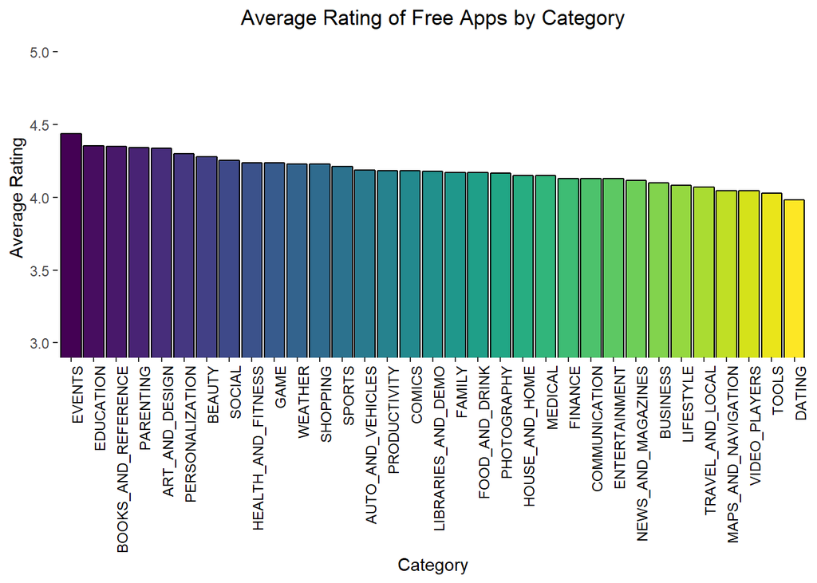

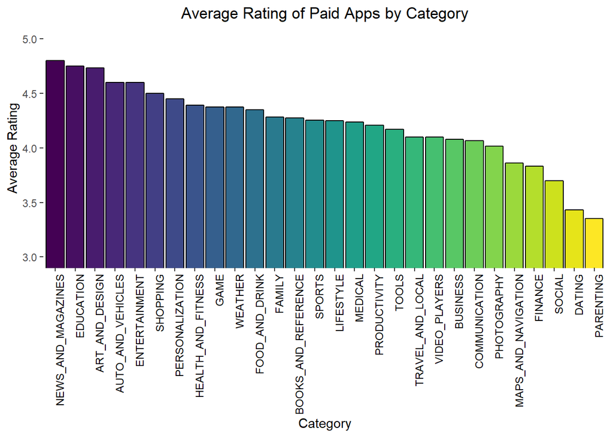

Do users rate free apps better than paid apps? Top 5 rated category in Free Apps

```
## # A tibble: 5 x 2
##   Category            Avg_rating
##   <fct>                    <dbl>
## 1 EVENTS                    4.44
## 2 EDUCATION                 4.35
## 3 BOOKS_AND_REFERENCE       4.35
## 4 PARENTING                 4.34
## 5 ART_AND_DESIGN            4.34
```

Top 5 rated category in Paid Apps

```
## # A tibble: 5 x 2
##   Category           Avg_rating
##   <fct>                   <dbl>
## 1 NEWS_AND_MAGAZINES       4.8
## 2 EDUCATION                4.75
## 3 ART_AND_DESIGN           4.73
## 4 AUTO_AND_VEHICLES        4.6
## 5 ENTERTAINMENT            4.6
```

How is the content rating distributed between free and paid apps?

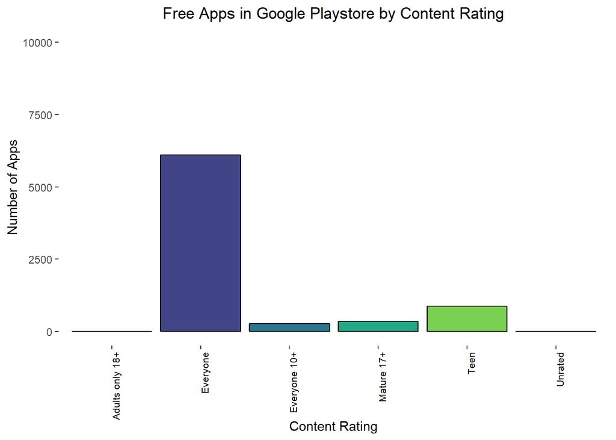

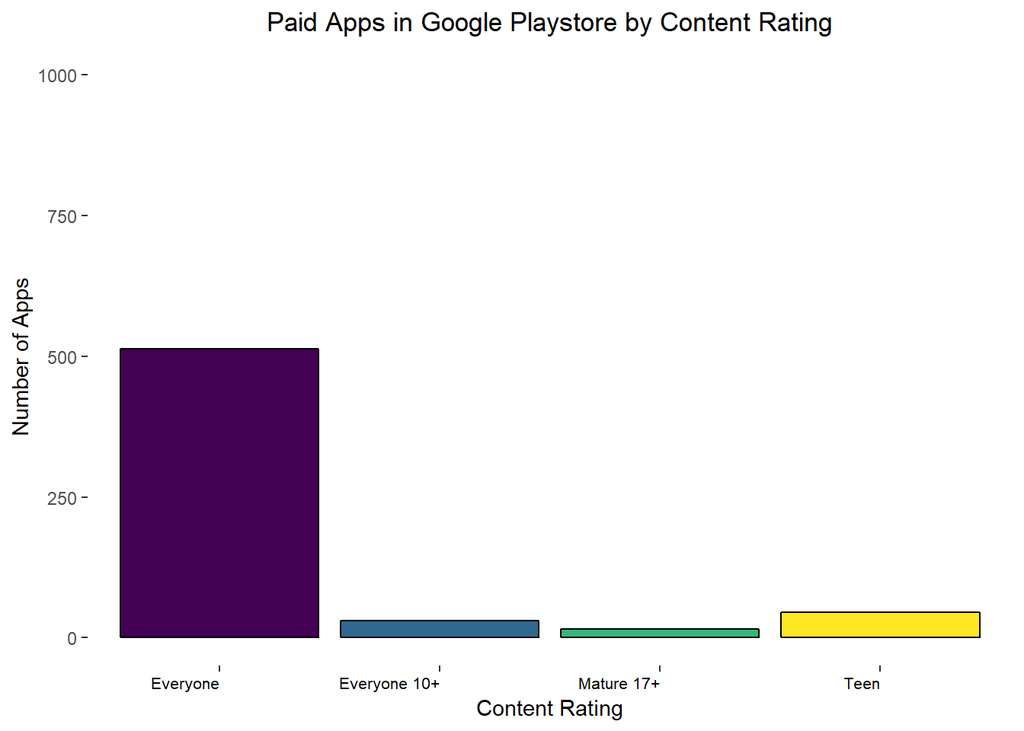

How are the apps distributed across different price categories

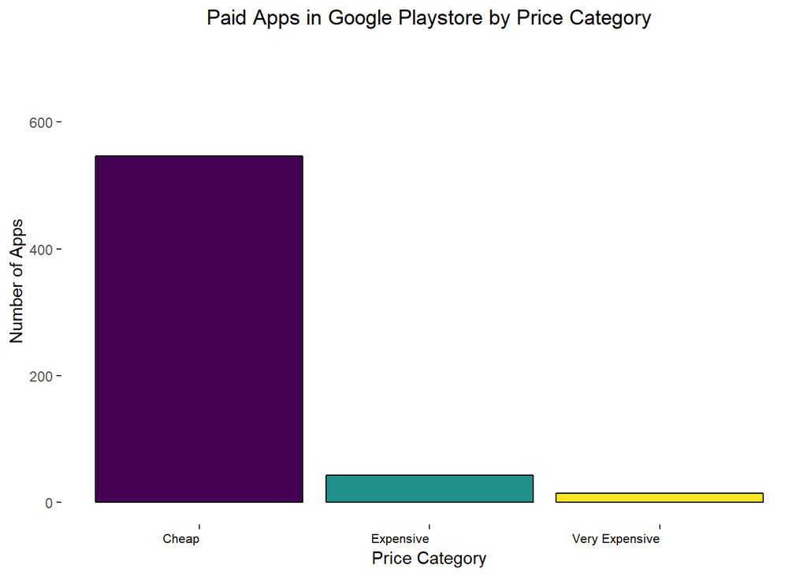

What are the average ratings across different price categories

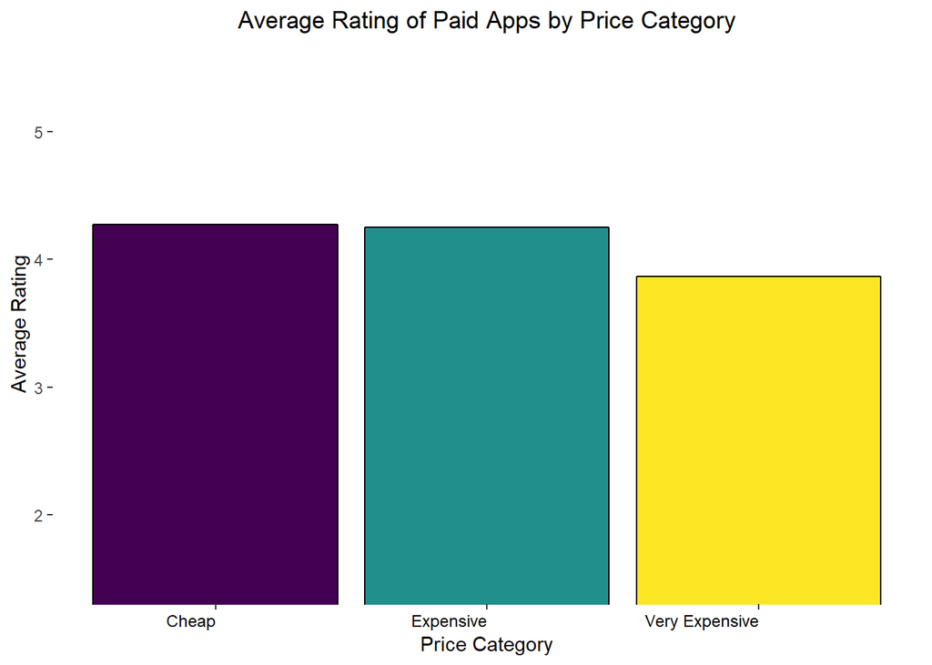

Are the average ratings the same across different price categories

```
##                Df Sum Sq Mean Sq F value Pr(>F)
## PriceCategory   2   2.39  1.1975   3.855 0.0217 *
## Residuals     601 186.68  0.3106
## ---
## Signif. codes:  0 '***' 0.001 '**' 0.01 '*' 0.05 '.' 0.1 ' ' 1
```

```
## [1] 0.02169438
```

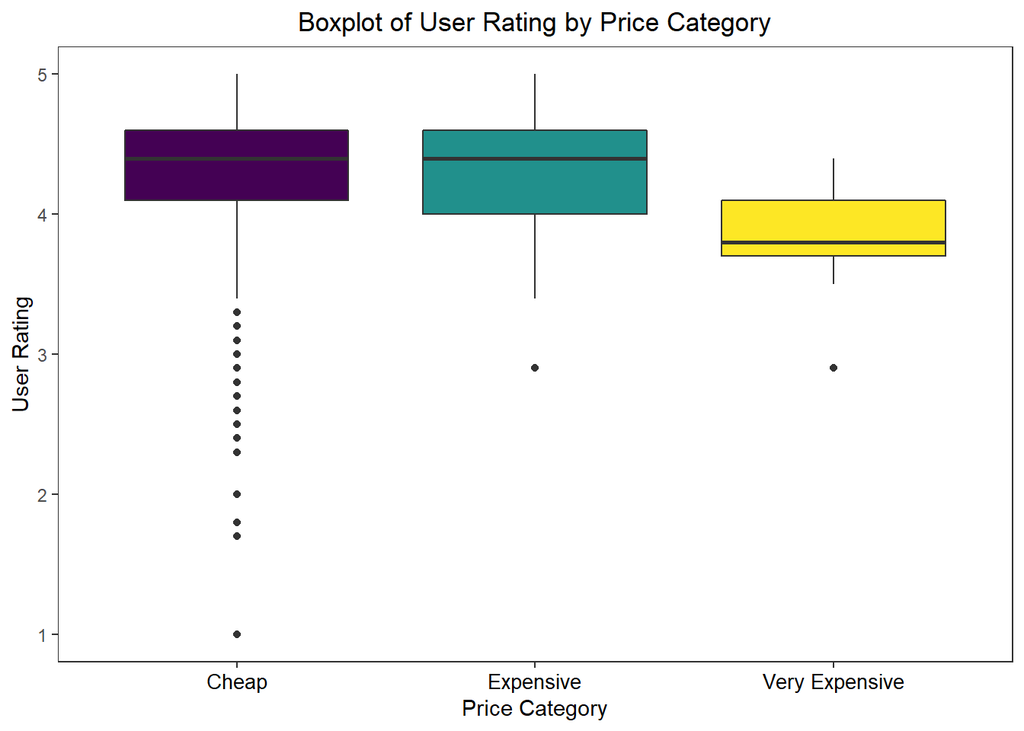

Are the average installed apps the same across different price categories

```
##                Df    Sum Sq   Mean Sq F value Pr(>F)
## PriceCategory   2 4.074e+11 2.037e+11   0.562   0.57
## Residuals     601 2.178e+14 3.624e+11
```

```
## [1] 0.5703626
```

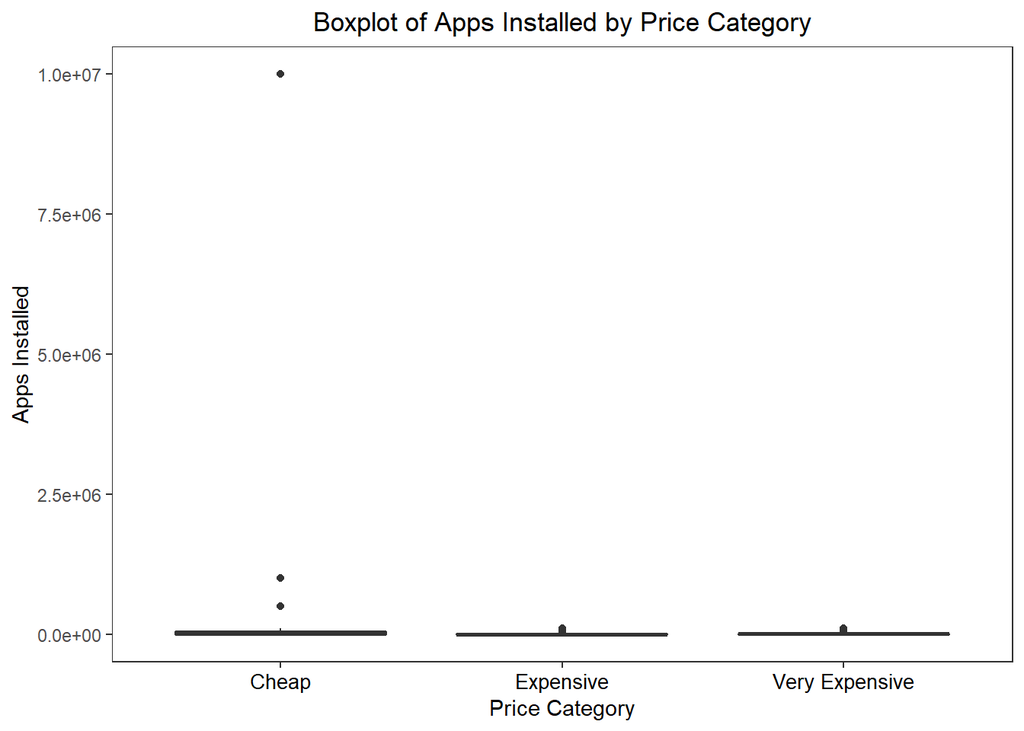

```
## 'data.frame':    604 obs. of  3 variables:
##  $ Rating  : num  4.7 4.8 4 4.2 2.6 3.5 4.9 4.7 4.7 4.7 ...
##  $ Installs: num  1e+05 1e+05 1e+05 1e+04 1e+03 1e+02 1e+03 1e+03 5e+05 1e+05 ...
##  $ Price   : num  4.99 4.99 3.99 3.99 6.99 7.99 3.99 5.99 3.99 3.99 ...
```

Get Correlation Matrix

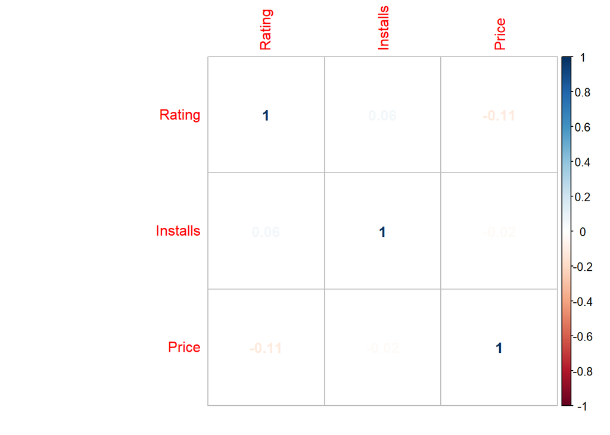

Carry out fitting with linear models

```
##
## Call:
## lm(formula = Rating ~ Price, data = lcpaidApps)
##
## Residuals:
##     Min      1Q  Median      3Q     Max
## -3.2727 -0.1691  0.1289  0.3298  0.7569
##
## Coefficients:
##               Estimate Std. Error t value Pr(>|t|)
## (Intercept)  4.2742466  0.0232622 183.742  < 2e-16 ***
## Price       -0.0010398  0.0003739  -2.781  0.00559 **
## ---
## Signif. codes:  0 '***' 0.001 '**' 0.01 '*' 0.05 '.' 0.1 ' ' 1
##
## Residual standard error: 0.5569 on 602 degrees of freedom
## Multiple R-squared:  0.01268,    Adjusted R-squared:  0.01104
## F-statistic: 7.733 on 1 and 602 DF,  p-value: 0.005592
```

```
##
## Call:
## lm(formula = Rating ~ Installs, data = lcpaidApps)
##
## Residuals:
##     Min      1Q  Median      3Q     Max
## -3.2543 -0.1549  0.1451  0.3454  0.7457
##
## Coefficients:
##              Estimate Std. Error t value Pr(>|t|)
## (Intercept) 4.254e+00  2.304e-02 184.611   <2e-16 ***
## Installs    5.576e-08  3.787e-08   1.472    0.141
## ---
## Signif. codes:  0 '***' 0.001 '**' 0.01 '*' 0.05 '.' 0.1 ' ' 1
##
## Residual standard error: 0.5594 on 602 degrees of freedom
## Multiple R-squared:  0.003588,   Adjusted R-squared:  0.001933
## F-statistic: 2.168 on 1 and 602 DF,  p-value: 0.1414
```

```
##
## Call:
## lm(formula = Rating ~ Price + Installs, data = lcpaidApps)
##
## Residuals:
##     Min      1Q  Median      3Q     Max
## -3.2675 -0.1656  0.1325  0.3335  0.7618
##
## Coefficients:
##               Estimate Std. Error t value Pr(>|t|)
## (Intercept)  4.269e+00  2.354e-02 181.385  < 2e-16 ***
## Price       -1.027e-03  3.737e-04  -2.749  0.00615 **
## Installs     5.333e-08  3.767e-08   1.415  0.15746
## ---
## Signif. codes:  0 '***' 0.001 '**' 0.01 '*' 0.05 '.' 0.1 ' ' 1
##
## Residual standard error: 0.5564 on 601 degrees of freedom
## Multiple R-squared:  0.01596,    Adjusted R-squared:  0.01269
## F-statistic: 4.875 on 2 and 601 DF,  p-value: 0.007942
```

```
##    Price Installs
## 1.000552 1.000552
```

[output not shown]

## Section 6: Popularity Variable

Create a popularity variable by combining rating, reviews, number of downloads? - check for normality of rating and number of downloads separately - look at correlation between rating and number of downloads -need to convert to # - standardize each then add together?

Look at revenue

### Section 6.2: Basic Analysis of Rating and Installs

Correlation Plot

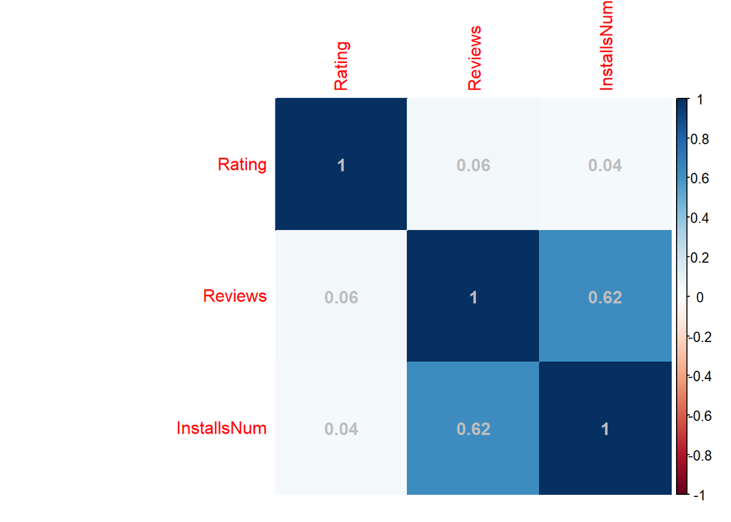

Check the normality of the ratings data.

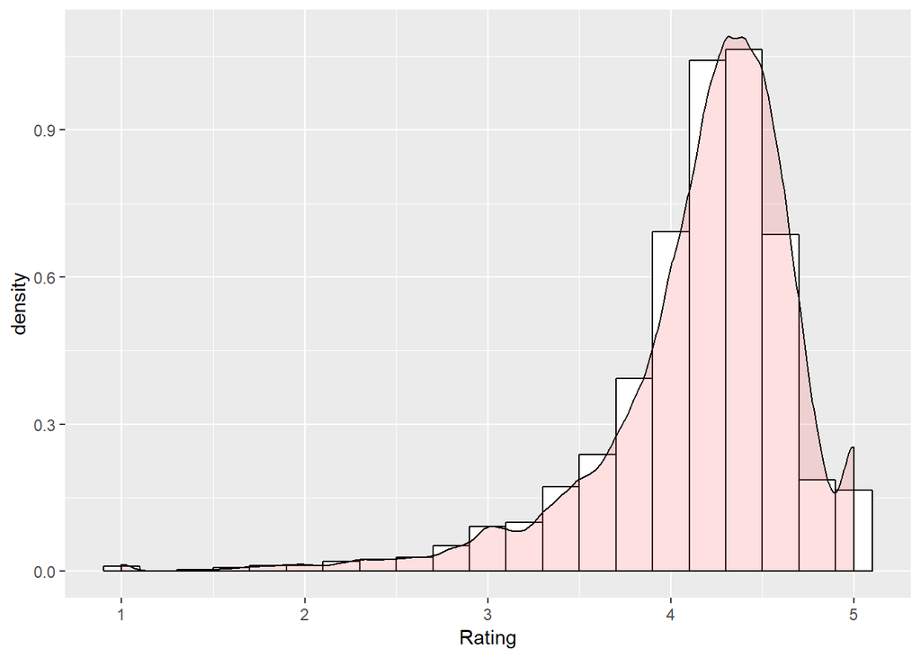

Check the normality of the number of downloads data. First need to aggregate the buckets so that they are in log scale.

NORMALITY ON A LOG SCALE?

```
## # A tibble: 10 x 2
##    InstallsLog    count
##    <ord>          <int>
##  1 1+                12
##  2 10+              125
##  3 100+             502
##  4 1,000+          1122
##  5 10,000+         1444
##  6 100,000+        1598
##  7 1,000,000+      2022
##  8 10,000,000+     1139
##  9 100,000,000+     212
## 10 1,000,000,000+    20
```

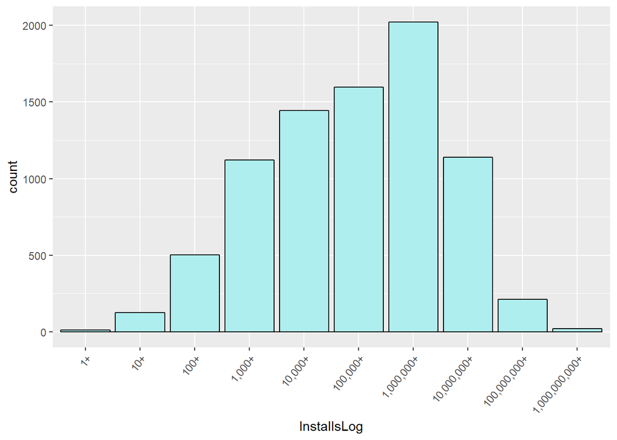

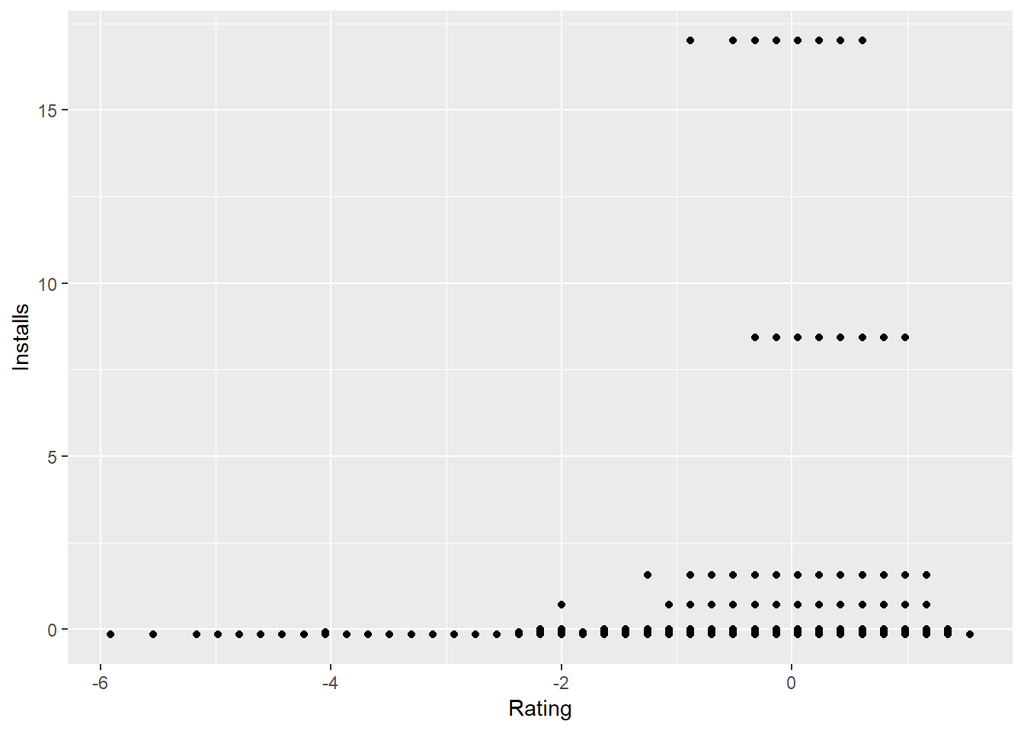